# Advanced Statistical Inference

# Gold Tier

For up to 6 points, use the leadership data found in the data folder. This is a .dta file (from Stata) and can be read in using the appropriate function from the haven package.

```r
leader <- haven::read_dta("leadership")
```

```r
summary(leader)
```

```
##     leaderID     OrganizationID     lvi01              lvi02
##  Min.   :    2   Min.   :  1    Min.   :-4.00000   Min.   :-4.0000
##  1st Qu.: 3366   1st Qu.: 21    1st Qu.: 0.00000   1st Qu.: 0.0000
##  Median : 7005   Median : 32    Median : 0.00000   Median : 0.0000
##  Mean   : 6827   Mean   : 48    Mean   : 0.07274   Mean   : 0.1076
##  3rd Qu.:10232   3rd Qu.: 81    3rd Qu.: 0.00000   3rd Qu.: 0.0000
##  Max.   :13397   Max.   :144    Max.   : 4.00000   Max.   : 4.0000
##                                 NA's   :84         NA's   :104
##      lvi03              lvi04              lvi05
##  Min.   :-4.00000   Min.   :-4.00000   Min.   :-4.00000
##  1st Qu.:-1.00000   1st Qu.: 0.00000   1st Qu.: 0.00000
##  Median : 0.00000   Median : 0.00000   Median : 0.00000
##  Mean   :-0.06743   Mean   : 0.00153   Mean   :-0.05603
##  3rd Qu.: 0.00000   3rd Qu.: 0.00000   3rd Qu.: 0.00000
##  Max.   : 4.00000   Max.   : 4.00000   Max.   : 4.00000
##  NA's   :94         NA's   :238        NA's   :179
##      lvi06             lvi07             lvi08             lvi09
##  Min.   :-4.0000   Min.   :-4.0000   Min.   :-4.0000   Min.   :-4.0000
##  1st Qu.: 0.0000   1st Qu.: 0.0000   1st Qu.: 0.0000   1st Qu.:-1.0000
##  Median : 0.0000   Median : 0.0000   Median : 0.0000   Median : 0.0000
##  Mean   :-0.1516   Mean   : 0.1597   Mean   : 0.2069   Mean   :-0.0146
##  3rd Qu.: 0.0000   3rd Qu.: 0.0000   3rd Qu.: 0.0000   3rd Qu.: 0.0000
##  Max.   : 4.0000   Max.   : 4.0000   Max.   : 4.0000   Max.   : 4.0000
##  NA's   :131       NA's   :93        NA's   :376       NA's   :427
##      lvi10             lvi11             lvi12             lvi13
##  Min.   :-4.0000   Min.   :-4.0000   Min.   :-4.0000   Min.   :-4.0000
##  1st Qu.: 0.0000   1st Qu.:-1.0000   1st Qu.:-1.0000   1st Qu.: 0.0000
##  Median : 0.0000   Median : 0.0000   Median : 0.0000   Median : 0.0000
##  Mean   : 0.1769   Mean   :-0.2783   Mean   :-0.2669   Mean   :-0.2619
##  3rd Qu.: 0.0000   3rd Qu.: 0.0000   3rd Qu.: 0.0000   3rd Qu.: 0.0000
##  Max.   : 4.0000   Max.   : 4.0000   Max.   : 4.0000   Max.   : 4.0000
##  NA's   :349       NA's   :1196      NA's   :1341      NA's   :218
##      lvi14             lvi15             lvi16             lvi17
##  Min.   :-4.0000   Min.   :-4.0000   Min.   :-4.0000   Min.   :-4.0000
##  1st Qu.: 0.0000   1st Qu.: 0.0000   1st Qu.: 0.0000   1st Qu.:-1.0000
##  Median : 0.0000   Median : 0.0000   Median : 0.0000   Median : 0.0000
##  Mean   :-0.1229   Mean   :-0.1649   Mean   :-0.1378   Mean   :-0.3524
##  3rd Qu.: 0.0000   3rd Qu.: 0.0000   3rd Qu.: 0.0000   3rd Qu.: 0.0000
##  Max.   : 4.0000   Max.   : 4.0000   Max.   : 4.0000   Max.   : 4.0000
##  NA's   :178       NA's   :187       NA's   :156       NA's   :250
```

[output cut: 49 more lines]

```
##  Min.   :-4.0000   Min.   :-4.0000   Min.   :-4.0000   Min.   :-4.0000
##  1st Qu.: 0.0000   1st Qu.: 0.0000   1st Qu.: 0.0000   1st Qu.: 0.0000
##  Median : 0.0000   Median : 0.0000   Median : 0.0000   Median : 0.0000
##  Mean   :-0.1924   Mean   :-0.2129   Mean   :-0.0608   Mean   :-0.0684
##  3rd Qu.: 0.0000   3rd Qu.: 0.0000   3rd Qu.: 0.0000   3rd Qu.: 0.0000
##  Max.   : 4.0000   Max.   : 4.0000   Max.   : 4.0000   Max.   : 4.0000
##  NA's   :792       NA's   :1348      NA's   :695       NA's   :622
##      lvi46             lvi47             lvi48             effect
##  Min.   :-4.0000   Min.   :-4.0000   Min.   :-4.0000   Min.   : 0.000
##  1st Qu.: 0.0000   1st Qu.: 0.0000   1st Qu.: 0.0000   1st Qu.: 7.500
##  Median : 0.0000   Median : 0.0000   Median : 0.0000   Median : 8.500
##  Mean   :-0.1205   Mean   :-0.2393   Mean   :-0.2613   Mean   : 8.152
##  3rd Qu.: 0.0000   3rd Qu.: 0.0000   3rd Qu.: 0.0000   3rd Qu.: 9.000
##  Max.   : 4.0000   Max.   : 4.0000   Max.   : 4.0000   Max.   :10.000
##  NA's   :1264      NA's   :445       NA's   :407       NA's   :2
```

Using verbs from the dplyr package (specifically, `group_by` and `summarize`), find the *effect* mean for each leaderID. Which leader(s) had the highest effect mean and which leader(s) had the lowest effect mean.

```r
leadereffect <- leader%>%
  group_by(leaderID)%>%
  dplyr::summarize(meaneffect = mean(effect,na.rm = TRUE))
```

Take your highest and lowest leaders and keep the leaderID. With the leaderID in hand, find those leaders in the leadershipRatingsAgreement data.

Excluding effect, construct a plot with forceful, enabling, strategic, operational, vitality, and productivity on the x-axis (the y-axis will contain the value for each variable). Next color the points by leaderID.

```r
minleaderid = leadereffect$leaderID[leadereffect$meaneffect == min(leadereffect$meaneffect)]
maxleaderid = leadereffect$leaderID[leadereffect$meaneffect == max(leadereffect$meaneffect)]

print(minleaderid)
```

```
## [1] 1589
```

```r
print(maxleaderid)
```

```
## [1] 1644 2507 8467
```

minID:1589 maxID:1644,2507,8467

```r
leadertotal <- leadership%>%
  filter((leaderID == 1589)|(leaderID == 1644) |(leaderID == 2507)|(leaderID == 8467))%>%
  select(-effect)%>%
  gather(class,number,-leaderID)
```

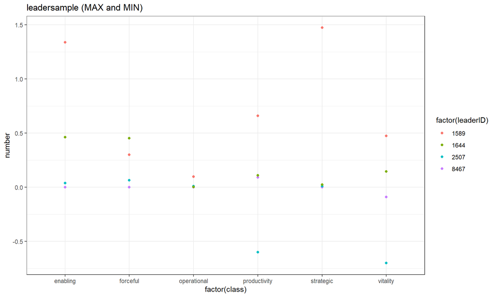

```r
ggplot(leadertotal, aes(x = factor(class), y = number, color = factor(leaderID))) +
  geom_point(stat = "identity",position = "dodge") +
  theme_bw() +
  ggtitle("leadersample (MAX and MIN)")
```

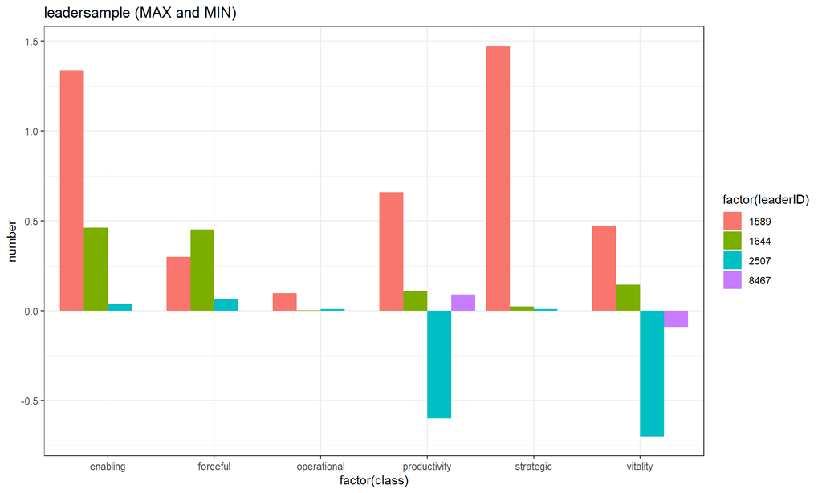

```r
ggplot(leadertotal, aes(x = factor(class), y = number, fill = factor(leaderID))) +
  geom_bar(stat = "identity",position = "dodge") +
  theme_bw() +
  ggtitle("leadersample (MAX and MIN)")
```